# Classification Tree bbdd reducido_plus

Grupo 5

# Base de datos reducido_plus SIN BALANCEAR

```r
data4tree<-data_reducida_plus[0:7000,]
datatest<-data_reducida_plus[7001:10000,]
ind <- sample(1:nrow(data4tree), 0.7*nrow(data4tree))
train <- data4tree[ind,]
test <- data4tree[-ind,]
```

## Método cp=0

```r
tree <- rpart(Exited ~ ., data = train, cp = 0)
printcp(tree)
```

```
##
## Classification tree:
## rpart(formula = Exited ~ ., data = train, cp = 0)
##
## Variables actually used in tree construction:
## [1] Age                 Balance             CreditScore
## [4] EstimatedSalary     Gender              Geography
## [7] IsActiveMember      NumOfProducts_grupo
##
## Root node error: 1029/4900 = 0.21
##
## n= 4900
##
##            CP nsplit rel error  xerror     xstd
## 1  0.01943635      0   1.00000 1.00000 0.027708
```

[output cut: 25 more lines]

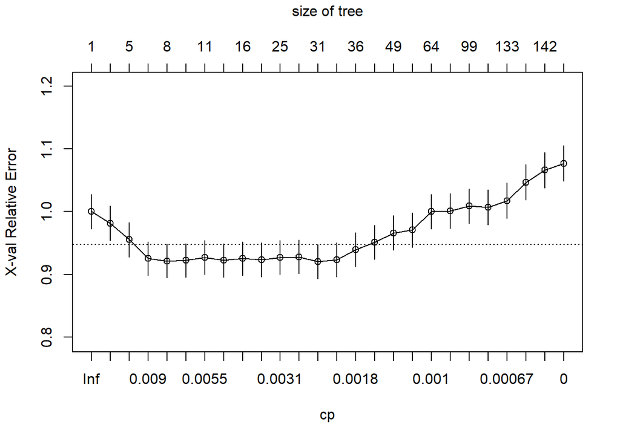

```r
plotcp(tree)
```

### Elección cp óptimo

```r
xerror <- tree$cptable[,"xerror"]
xerror
```

```
##         1         2         3         4         5         6         7         8
## 1.0000000 0.9815355 0.9552964 0.9251701 0.9212828 0.9222546 0.9271137 0.9222546
##         9        10        11        12        13        14        15        16
## 0.9251701 0.9232264 0.9271137 0.9280855 0.9203110 0.9232264 0.9397473 0.9514091
##        17        18        19        20        21        22        23        24
## 0.9659864 0.9708455 1.0000000 1.0009718 1.0087464 1.0068027 1.0174927 1.0466472
##        25        26
## 1.0660836 1.0767736
```

```r
imin.xerror <- which.min(xerror)
imin.xerror
```

```
## 13
## 13
```

```r
tree$cptable[imin.xerror, ]
```

```
##           CP       nsplit    rel error       xerror         xstd
##  0.002429543 30.000000000  0.795918367  0.920310982  0.026861173
```

```r
upper.xerror <- xerror[imin.xerror] + tree$cptable[imin.xerror, "xstd"]
upper.xerror
```

```
##        13
## 0.9471722
```

#### Cp mínimo

```r
tree2 <- prune(tree, cp = 0.002967359)
importance <- tree2$variable.importance
importance <- round(100*importance/sum(importance), 1)
importance
```

```
##                 Age NumOfProducts_grupo             Balance      IsActiveMember
##                41.6                32.6                 8.2                 5.8
##         CreditScore     EstimatedSalary           Geography              Gender
##                 4.2                 3.2                 2.3                 2.1
```

Matriz de confusión para train

```
## Confusion Matrix and Statistics
##
##           Reference
## Prediction    0    1
##          0 3369  541
##          1  502  488
##
##                Accuracy : 0.7871
##                  95% CI : (0.7754, 0.7985)
##     No Information Rate : 0.79
##     P-Value [Acc > NIR] : 0.6953
##
##                   Kappa : 0.3494
##
##  Mcnemar's Test P-Value : 0.2393
##
##             Sensitivity : 0.47425
##             Specificity : 0.87032
##          Pos Pred Value : 0.49293
##          Neg Pred Value : 0.86164
##              Prevalence : 0.21000
##          Detection Rate : 0.09959
##    Detection Prevalence : 0.20204
##       Balanced Accuracy : 0.67228
##
##        'Positive' Class : 1
##
```

Matriz de confusión para test

```
## Confusion Matrix and Statistics
##
##           Reference
## Prediction    0    1
##          0 1456  228
##          1  223  193
##
##                Accuracy : 0.7852
##                  95% CI : (0.767, 0.8026)
##     No Information Rate : 0.7995
##     P-Value [Acc > NIR] : 0.9509
##
##                   Kappa : 0.3271
##
##  Mcnemar's Test P-Value : 0.8506
##
##             Sensitivity : 0.4584
##             Specificity : 0.8672
##          Pos Pred Value : 0.4639
##          Neg Pred Value : 0.8646
##              Prevalence : 0.2005
##          Detection Rate : 0.0919
##    Detection Prevalence : 0.1981
##       Balanced Accuracy : 0.6628
##
##        'Positive' Class : 1
##
```

F1 score

```
## f1 datos train 0.4834076 f1 datos test 0.4611708
```

#### Cp mínimo+ error estándar

```r
icp <- which(tree$cptable[, "xerror"] <= upper.xerror)[1]
cp_optimo_1se <- tree$cptable[icp, "CP"]
tree3 <- prune(tree, cp = cp_optimo_1se)
importance <- tree3$variable.importance
importance <- round(100*importance/sum(importance), 1)
importance
```

```
##                 Age NumOfProducts_grupo      IsActiveMember             Balance
##                44.9                40.2                 7.8                 6.1
##     EstimatedSalary         CreditScore              Gender
##                 0.4                 0.3                 0.2
```

Vemos como han cambiado los valores de importancia. Ahora se comprovará si mejoran los KPI. Matriz de confusión para train

```
## Confusion Matrix and Statistics
##
##           Reference
## Prediction    0    1
##          0 3322  538
##          1  549  491
##
##                Accuracy : 0.7782
##                  95% CI : (0.7663, 0.7897)
##     No Information Rate : 0.79
##     P-Value [Acc > NIR] : 0.9794
##
##                   Kappa : 0.334
##
##  Mcnemar's Test P-Value : 0.7617
##
##             Sensitivity : 0.4772
##             Specificity : 0.8582
##          Pos Pred Value : 0.4721
##          Neg Pred Value : 0.8606
##              Prevalence : 0.2100
##          Detection Rate : 0.1002
##    Detection Prevalence : 0.2122
##       Balanced Accuracy : 0.6677
##
##        'Positive' Class : 1
##
```

Matriz de confusión para test

```
## Confusion Matrix and Statistics
##
##           Reference
## Prediction    0    1
##          0 1442  225
##          1  237  196
##
##                Accuracy : 0.78
##                  95% CI : (0.7617, 0.7976)
##     No Information Rate : 0.7995
##     P-Value [Acc > NIR] : 0.9875
##
##                   Kappa : 0.321
##
##  Mcnemar's Test P-Value : 0.6088
##
##             Sensitivity : 0.46556
##             Specificity : 0.85884
##          Pos Pred Value : 0.45266
##          Neg Pred Value : 0.86503
##              Prevalence : 0.20048
##          Detection Rate : 0.09333
##    Detection Prevalence : 0.20619
##       Balanced Accuracy : 0.66220
##
##        'Positive' Class : 1
##
```

F1 score

```
## f1 datos train 0.4746254 f1 datos test 0.4590164
```

## Método Caret

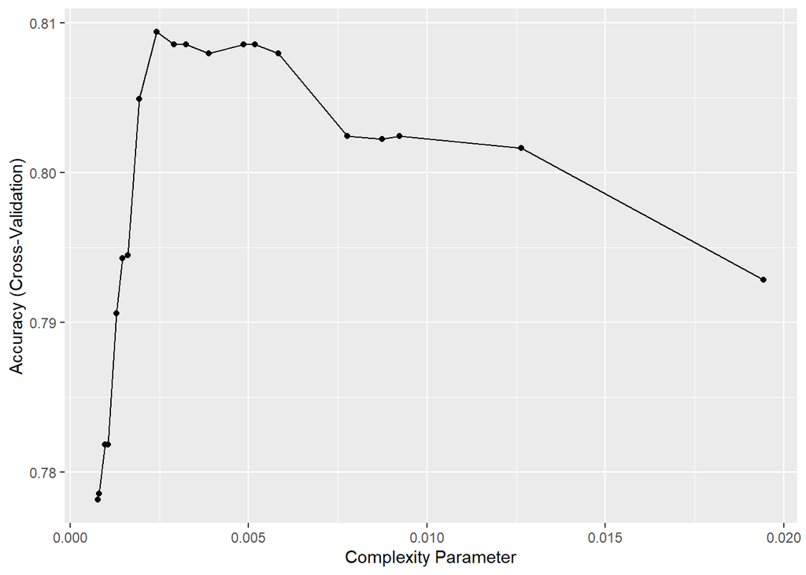

```r
caret.rpart <- train(Exited ~ ., method = "rpart", data = train,
 tuneLength = 20,
 trControl = trainControl(method = "cv", number = 10))
ggplot(caret.rpart)
```

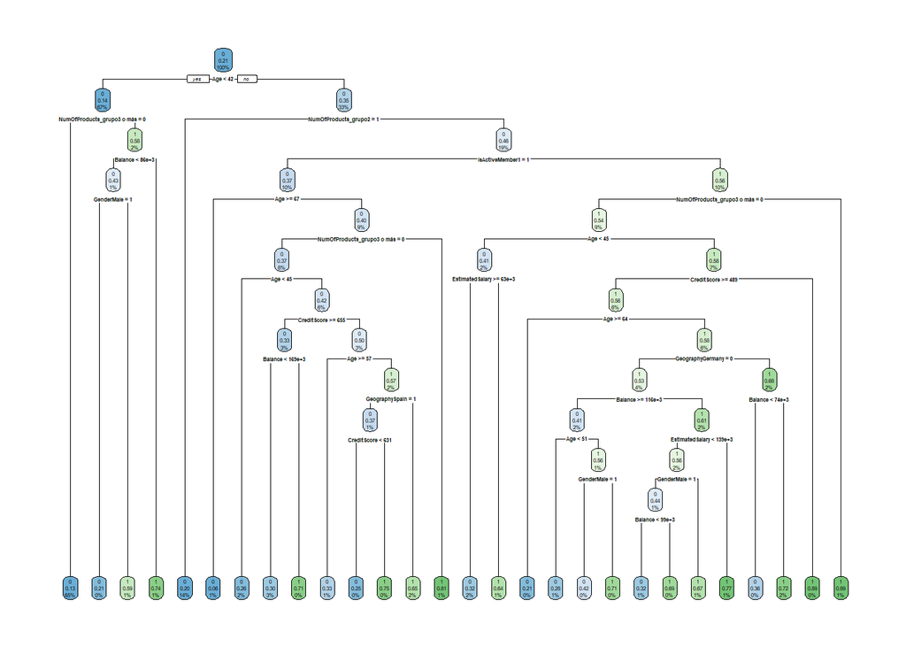

```r
rpart.plot(caret.rpart$finalModel)
```

Importancia de las variables:

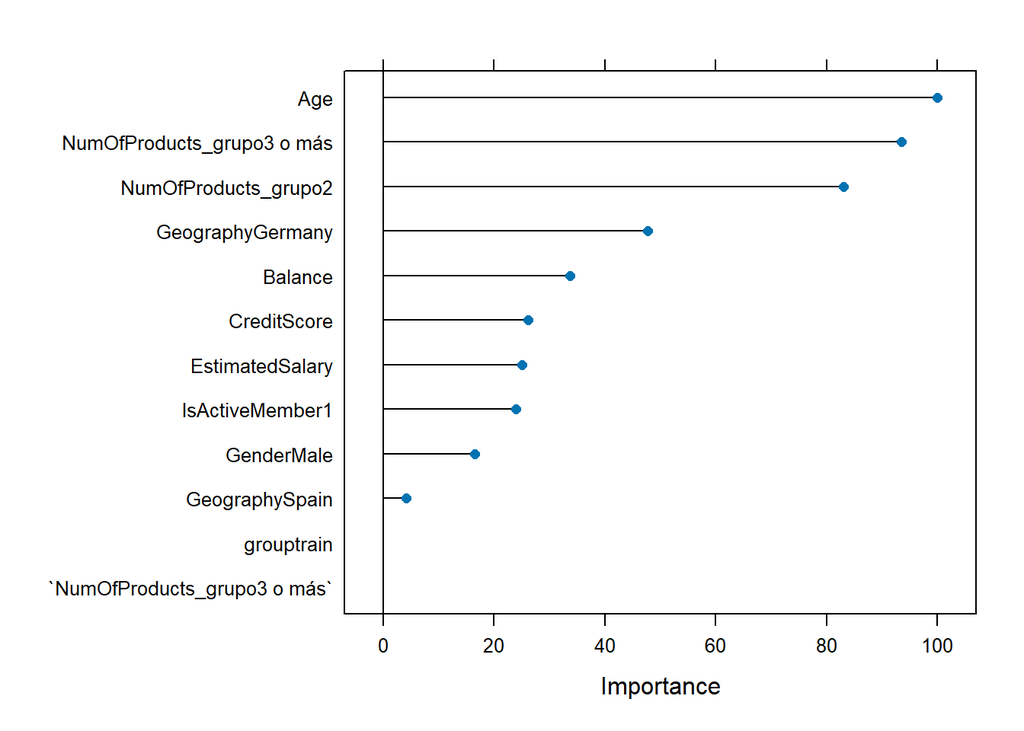

Las predicciones:

Matriz de confusión datos train

```
## Confusion Matrix and Statistics
##
##           Reference
## Prediction    0    1
##          0 3369  541
##          1  502  488
##
##                Accuracy : 0.7871
##                  95% CI : (0.7754, 0.7985)
##     No Information Rate : 0.79
##     P-Value [Acc > NIR] : 0.6953
##
##                   Kappa : 0.3494
##
##  Mcnemar's Test P-Value : 0.2393
##
##             Sensitivity : 0.47425
##             Specificity : 0.87032
##          Pos Pred Value : 0.49293
##          Neg Pred Value : 0.86164
##              Prevalence : 0.21000
##          Detection Rate : 0.09959
##    Detection Prevalence : 0.20204
##       Balanced Accuracy : 0.67228
##
##        'Positive' Class : 1
##
```

Matriz de confusión datos test:

```
## Confusion Matrix and Statistics
##
##           Reference
## Prediction    0    1
##          0 1442  225
##          1  237  196
##
##                Accuracy : 0.78
##                  95% CI : (0.7617, 0.7976)
##     No Information Rate : 0.7995
##     P-Value [Acc > NIR] : 0.9875
##
##                   Kappa : 0.321
##
##  Mcnemar's Test P-Value : 0.6088
##
##             Sensitivity : 0.46556
##             Specificity : 0.85884
##          Pos Pred Value : 0.45266
##          Neg Pred Value : 0.86503
##              Prevalence : 0.20048
##          Detection Rate : 0.09333
##    Detection Prevalence : 0.20619
##       Balanced Accuracy : 0.66220
##
##        'Positive' Class : 1
##
```

Los F1score:

```
## f1 datos train 0.4834076 f1 datos test 0.4590164
```

- Valores muy pobres de F1 y recall
- Indicios de overfitting

## Conclusiones para data_reducido_plus sin balancear

Resultados bastante mejorables tanto con el paquete Caret como encontrando el Cp óptimo a partir del árbol más grande (Cp=0). Sumar la desviación típica tampoco mejora los resultados. Probaremos balanceando los datos.

# Base de datos reducido_plus BALANCEO

A continuación se buscará para diferentes niveles de balanceo dónde se obtienen mejores kpi con caret

[output not shown]

```
##          F1_Train    F1_Test Sensitivity_Train Sensitivity_Test
## p_0.05 0.06922357 0.06422018        0.03595724       0.03325416
## p_0.1  0.08155700 0.09029345        0.04275996       0.04750594
## p_0.15 0.17317487 0.17427386        0.09912536       0.09976247
## p_0.2  0.39491299 0.36038961        0.28668610       0.26365796
## p_0.25 0.42380085 0.38766520        0.33916424       0.31353919
## p_0.3  0.45046083 0.44289694        0.37998056       0.37767221
## p_0.35 0.46509130 0.43622449        0.42079689       0.40617577
## p_0.4  0.51604278 0.44812362        0.56268222       0.48218527
## p_0.45 0.49742710 0.47629083        0.56365403       0.53681710
## p_0.5  0.47712640 0.43853821        0.68415938       0.62707838
##        Specificity_Train Specificity_Test Accuracy_Train Accuracy_Test
## p_0.05         0.9992250        0.9994044      0.7969388     0.8057143
## p_0.1          0.9984500        0.9988088      0.7977551     0.8080952
## p_0.15         0.9878584        0.9886837      0.8012245     0.8104762
## p_0.2          0.9560837        0.9499702      0.8155102     0.8123810
## p_0.25         0.9305089        0.9237641      0.8063265     0.8014286
## p_0.3          0.9183673        0.9178082      0.8053061     0.8095238
## p_0.35         0.8966675        0.8856462      0.7967347     0.7895238
## p_0.4          0.8357014        0.8320429      0.7783673     0.7619048
## p_0.45         0.8132266        0.8201310      0.7608163     0.7633333
## p_0.5          0.6853526        0.6908874      0.6851020     0.6780952
```